# Esquisse Data Visualization Lab - Key

First, make sure you install and load the `esquisse` package using `install.packages` and `library`:

```r
install.packages("esquisse")
install.packages("ggplot2")
```

```r
library(esquisse)
library(ggplot2)
library(tidyverse)
```

Let’s look at the relationship between exposure to pollution and visits to the ER for asthma issues.

`CES4.0Percentile`: a measure of how much pollution people in a census tract experience, relative to the other census tracts in California

`Asthma`: Age-adjusted rate of emergency department visits for asthma

`ChildrenPercLess10`: estimates of the percent per census tract of children under 10 years old

This dataset has a lot of variables, so first run the below code to subset it so that you’re only working with these variables: `CES4.0Percentile`, `Asthma`, and `ChildrenPercLess10`. We will also categorize `CES4.0Percentile` into three categories (high, middle, and low) to make visualization a little easier!

```r
ces <- read_csv(file = "https://daseh.org/data/CalEnviroScreen_data.csv")
ces_sub <- select(ces, c("CES4.0Percentile", "Asthma", "ChildrenPercLess10"))

ces_sub <- ces_sub |>
            mutate(CES4.0Perc_cat =
              case_when(CES4.0Percentile > 75  ~ "High",
                        CES4.0Percentile <= 75 & CES4.0Percentile >25 ~ "Middle",
                        CES4.0Percentile <= 25 ~ "Low"))
```

### 1.1

Try creating a plot in `esquisse` using the `ces_sub` data.

- Drag and drop the `ChildrenPercLess10` variable to be plotted on the x-axis.
- Drag and drop the `Asthma` variable to be plotted on the y-axis.
- What happens when you drag `CES4.0Perc_cat` to the facet region of the esquisse GUI?
- What happens if you move this to color?
- Copy and paste the code from both options into the chunk below:

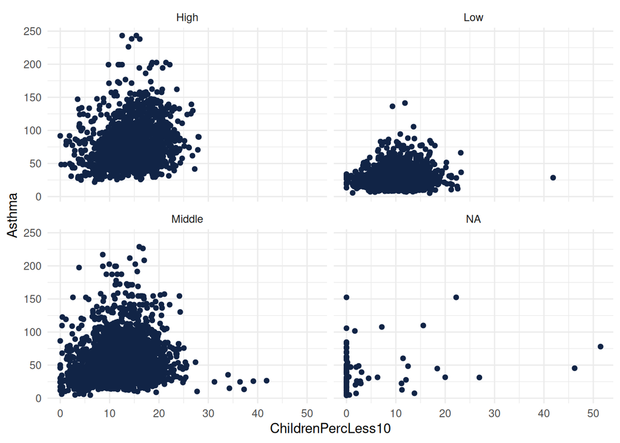

```r
# esquisser(ces_sub)
ggplot(ces_sub) +
  aes(x = ChildrenPercLess10, y = Asthma) +
  geom_point(shape = "circle", size = 1.5, colour = "#112446") +
  theme_minimal() +
  facet_wrap(vars(CES4.0Perc_cat))
```

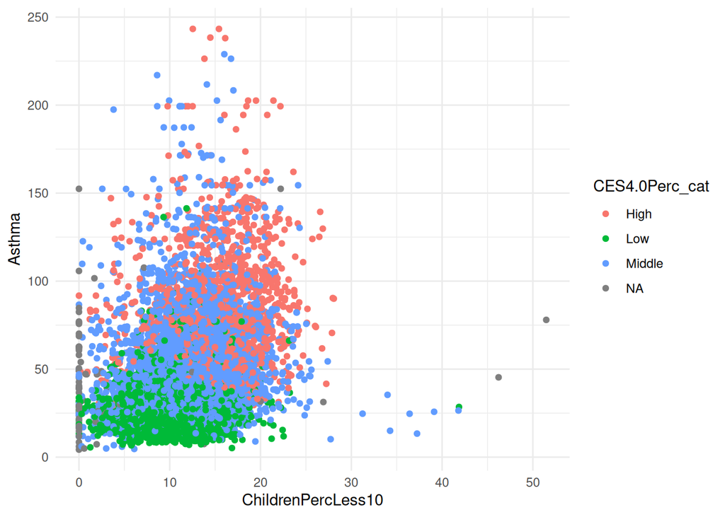

```r
ggplot(ces_sub) +
  aes(x = ChildrenPercLess10, y = Asthma, colour = CES4.0Perc_cat) +
  geom_point(shape = "circle", size = 1.5) +
  scale_color_hue(direction = 1) +
  theme_minimal()
```

### 1.2

Try creating a plot in `esquisse` using the `ces_sub` data.

- Drag and drop the `ChildrenPercLess10` variable to be plotted on the x-axis.
- Drag and drop the `Asthma` variable to be plotted on the y-axis.

Change the plot to a different type of plot. Copy and paste the code into the chunk below. Close Esquisse, and run the chunk below to generate a ggplot.

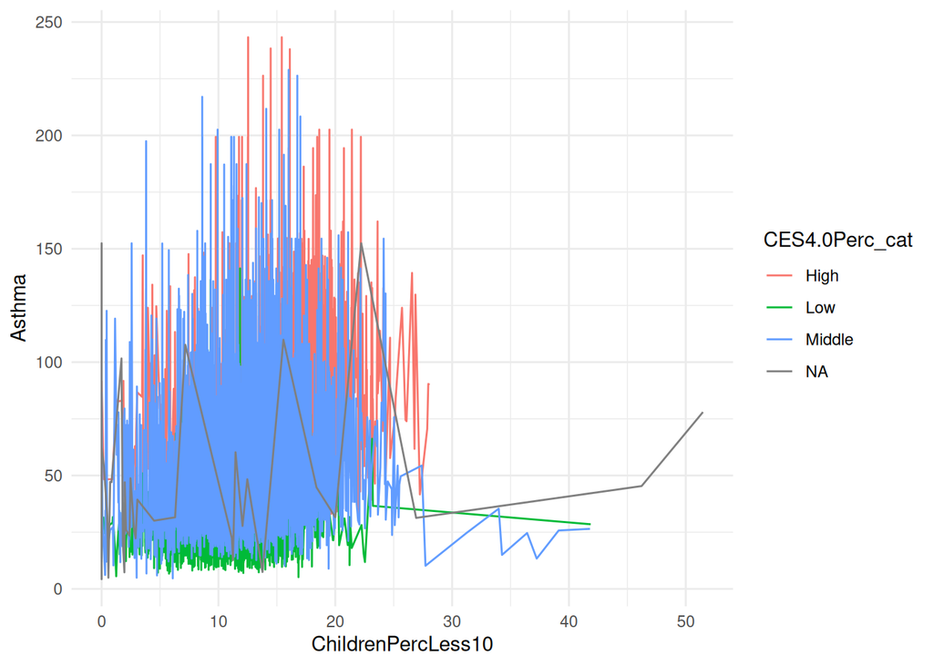

```r
ggplot(ces_sub) +
  aes(x = ChildrenPercLess10, y = Asthma, colour = CES4.0Perc_cat) +
  geom_line(size = 0.5) +
  scale_color_hue(direction = 1) +
  theme_minimal()
```

# Practice on Your Own!

### P.1

Launch Esquisse on any selection of the following datasets we have worked with before and explore!

```r
co2 <- read_csv("https://daseh.org/data/Yearly_CO2_Emissions_1000_tonnes.csv")
cc <- read_csv("https://daseh.org/data/Yearly_CC_disasters_total_affected.csv")
nitrate <- read_csv(file = "https://daseh.org/data/Nitrate_Exposure_for_WA_Public_Water_Systems_byquarter_data.csv")
# esquisser(nitrate)
```